# ANR BISE: Analyzing trophic webs accross agricultural sites with different treatments.

```r
knitr::opts_knit$set(root.dir = "D:/Knowledge-based/BISE/meta-bio-net/Bionet_V2/")
knitr::opts_knit$set(warning = FALSE, include=FALSE)
```

# Setting global parameters

# Knowledge base load and preparation

First, we load the knowledge base of ecological interactions.

```r
### Knowledge base ###
edge_kb= read.csv2(file_kwBase,dec=".")
cat("Knowledge base contains: ",dim(edge_kb)[1],"edges \n",sep=" ")
```

```
## Knowledge base contains:  423645 edges
```

Some statistics about our knowledge base so far …

```r
### Taxa related knowledge ###
#edge_kb$resource_rank%in%c("FAMILY","GENUS","SPECIES","RESOURCE")
resource_metadata=unique(edge_kb[,kb_resource_metadata])
consumer_metadata=unique(edge_kb[,kb_consumer_metadata])
colnames(resource_metadata)=colnames(consumer_metadata)=taxa_metadata_colnames
taxa_kb=unique(rbind(resource_metadata,consumer_metadata))

## Delete unused data ##
rm(resource_metadata)
rm(consumer_metadata)

cat("Knowledge base covers: ",dim(taxa_kb)[1],"taxa \n",sep=" ")
```

```
## Knowledge base covers:  3050 taxa
```

```r
#summary(taxa_metadata)
```

# Occurrence dataset load and preparation

Load motu occurrence dataset (the file has been preprocessed previously so that motu names match the taxonomy we’re using)

```r
### MOTU occurrence dataset ###
raw_metabar=read.csv2(file_occurBase)
### Occurrence columns ###
pt_names=sample_ids(raw_metabar)
metabar=subset(raw_metabar,rowSums(raw_metabar[,pt_names])>0)
cat("MOTU dataset contains: ",dim(metabar)[1],"motus \n",sep=" ")
```

```
## MOTU dataset contains:  5281 motus
```

```r
rm(raw_metabar)
fac<-read.csv2(experimental_setting)
```

Some MOTUs are assigned to taxa not covered in our knowledge base, we decided to drop them. However, a vast majority of MOTUs are well covered.

```r
### Filtering MOTUs not covered in knowledge base  ###
list_keys=unique(metabar[,metabar_taxa_metadata])
motu_uncovered=subset(list_keys,!(key %in% edge_kb$resource) & !(key%in% edge_kb$consumer))
motu_covered=subset(list_keys,key %in% edge_kb$resource | key%in% edge_kb$consumer)
cat("MOTU coverage in knowledge base: ",100*dim(motu_covered)[1]/dim(list_keys)[1],"%\n")
```

```
## MOTU coverage in knowledge base:  97.77382 %
```

```r
rm(list_keys)
rm(motu_uncovered)
taxa_metadata=merge(motu_covered,taxa_kb,by="key")
#taxa_metadata=subset(o,rank%in%c("FAMILY","GENUS","SPECIES","RESOURCE"))
rm(motu_covered)
rm(taxa_kb)
```

We’ll subset part of the knowledge base that is of interest to the community composition we have in our hands.

```r
sub_edges=subset(edge_kb,edge_kb$resource%in%taxa_metadata$key & edge_kb$consumer%in%taxa_metadata$key)
  cat("Covered taxa in knowledge base are involved in ",dim(sub_edges)[1]," known interactions with proportions of trophic and parasitism of respectively: \n",100*(summary(sub_edges[,c("type")])/dim(sub_edges)[1]))
```

```
## Covered taxa in knowledge base are involved in  23417  known interactions with proportions of trophic and parasitism of respectively:
##  96.0029 3.997096
```

```r
rm(edge_kb)
```

We’ll now proceed to aggregating MOTUs assigned to the same taxon by summing their occurrences (read counts) in each sampling point.

```r
### Aggregating MOTU data to the occurrence point ###
cat("Selecting occurrences of covered taxa in the knowledge base \n")
```

```
## Selecting occurrences of covered taxa in the knowledge base
```

```r
submetabar=metabar[metabar$key %in%taxa_metadata$key,c("key",pt_names)]
rm(metabar)
agg_occur=aggregate(submetabar[,pt_names],
                    by=list(
                      key=submetabar$key),
                      #verbatimScientificName=submetabar$verbatimScientificName,
                      #broad=submetabar$broad),
                      FUN=sum)
rm(submetabar)
```

# Metaweb construction workflow

So, at this point we have all it takes to run the automated workflow, that is a nice knowledge base of interactions edge_kb and a ready to use occurrence dataset agg_occur all involving the subset of taxa described in taxa_metadata.

## Building the metaweb and computing metrics on projected networks

```r
alltaxa_analysis=meta_bionet_workflow(sub_edges,agg_occur,taxa_metadata,
                          name="BISE",pt_names=pt_names,
                          rank_filter=c("FAMILY","GENUS","SPECIES","RESOURCE"),
                               edge_ends=edge_ends,edge_attributes=edge_attributes,
                               weight_att=2,type_att=1,min_prob=min_prob,min_occur=min_occur,
                               verb=0)
```

```
## Creating node objects for the covered  1098  taxa
## Creating metaweb of trophic/parasitic interactions
## Metaweb:
##   Name: BISE
##  Network statistics:
##  Number of taxa: 1098
##  Number of interactions: 22669
##  Connectivity:  0.01882016Rank filter
## Projecting metaweb to local occurrence data, with minimum significant occurrence =  1
## Computing and saving network topology and energy pathways metrics
```

```r
saveRDS(alltaxa_analysis,file = file_alltaxa_rds)
### Saving statistics ###
write.csv2(cbind(fac,alltaxa_analysis$TopoEnMetrics),file=file_alphametrics_taxa,row.names = F)
```

## Network betadiversity metrics

Here, we analyze betadiversity between points …

First, we aggregate occurrences to the point level

```r
lnames=unlist(lapply(1:64, function(x) sprintf("BISE_%02d",x)))
lgroups=rep(lnames,each=4)
names(lgroups)=pt_names
agg_occur_pt<-aggregate_occur(agg_occur,pt_names,lgroups)
```

Then, we project the metaweb to the new occurrences:

```r
pointlevel_analysis=meta_bionet_workflow(sub_edges,agg_occur_pt$df,taxa_metadata,
                               name="BISE_PT",pt_names=lnames,
                          rank_filter=c("FAMILY","GENUS","SPECIES","RESOURCE"),
                               edge_ends=edge_ends,edge_attributes=edge_attributes,
                               weight_att=2,type_att=1,min_prob=min_prob,min_occur=min_occur,
                               verb=0)
```

```
## Creating node objects for the covered  1098  taxa
## Creating metaweb of trophic/parasitic interactions
## Metaweb:
##   Name: BISE_PT
##  Network statistics:
##  Number of taxa: 1098
##  Number of interactions: 22669
##  Connectivity:  0.01882016Rank filter
## Projecting metaweb to local occurrence data, with minimum significant occurrence =  1
## Computing and saving network topology and energy pathways metrics
```

Finally, we compute the betadiversity between the 64 point-level local networks

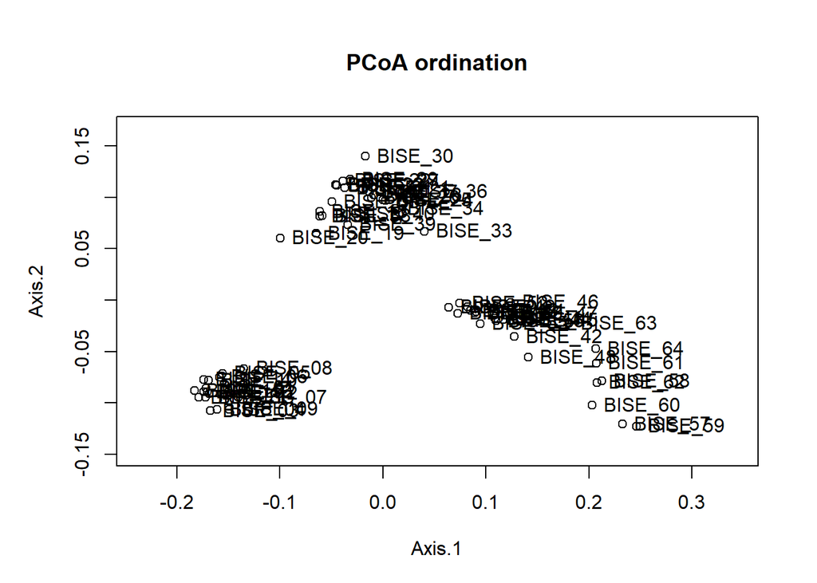

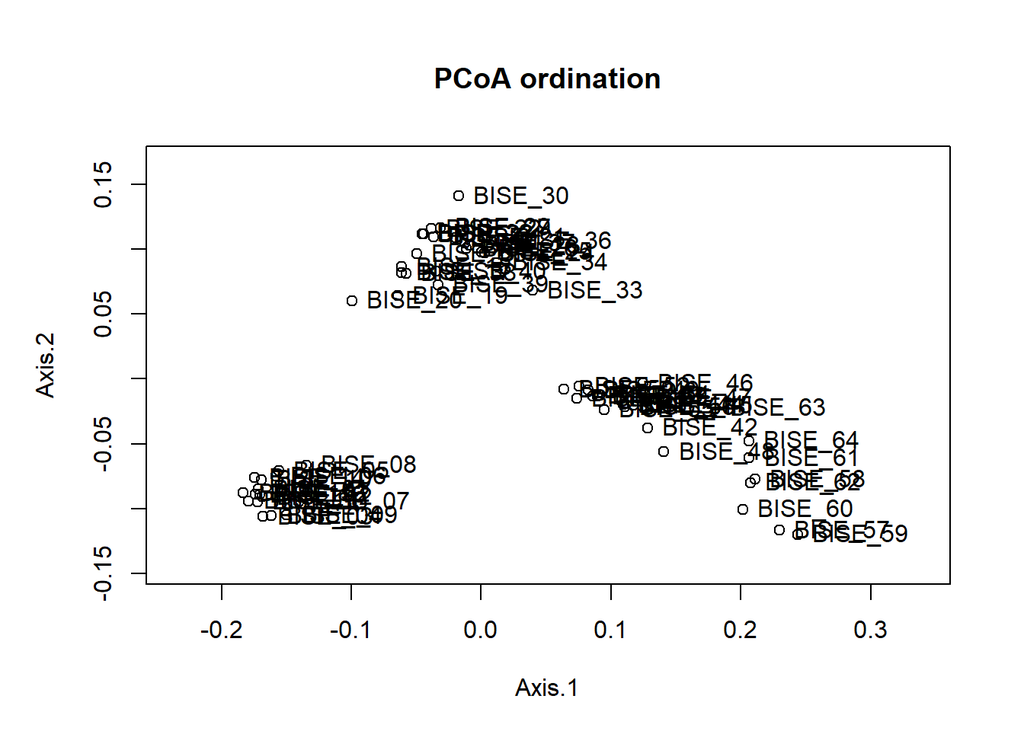

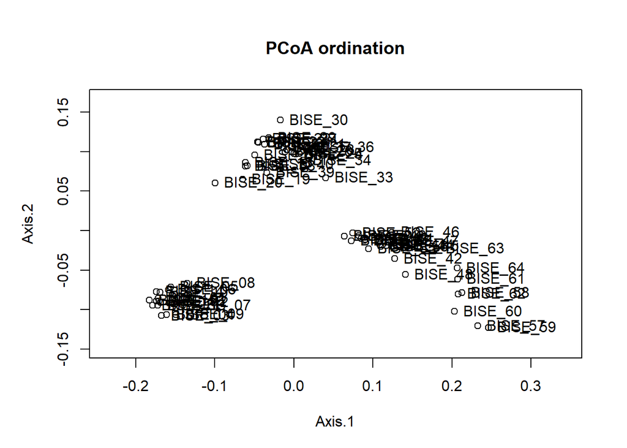

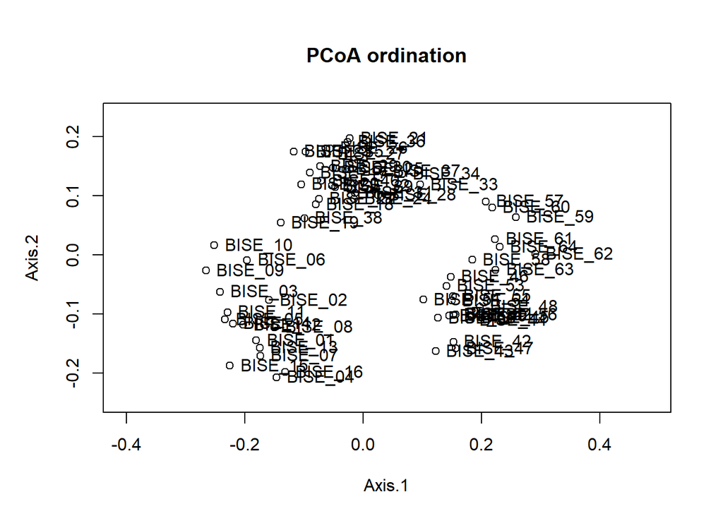

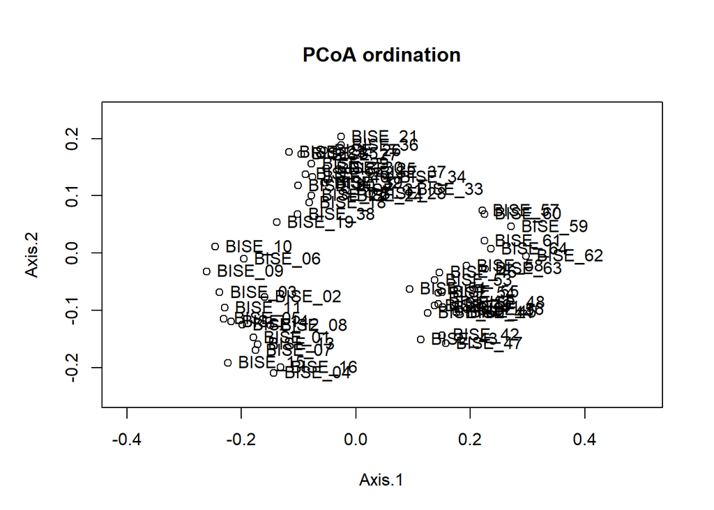

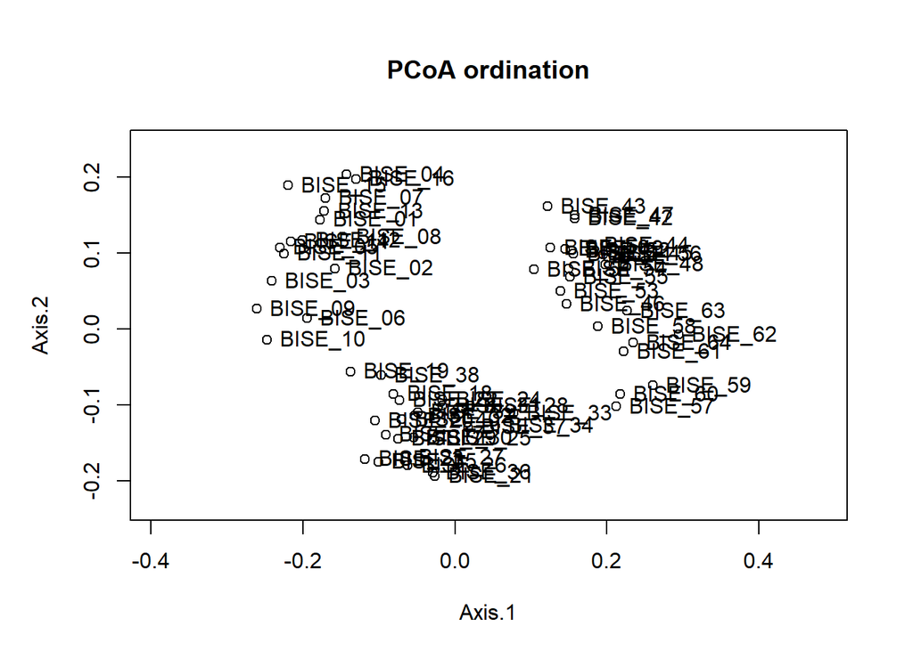

```r
eta=c(0,1,2)
divs=c('P','L')
if(betapt_done==0){
for (div in divs){
  for (e in eta){
      betadiv_ptdf=betanet(gList=pointlevel_analysis$SubNetworks,
                           file_beta = paste(file_beta_pt,"_",e,"_",div,".csv",sep=""),
                           pt_names = lnames,div=div,eta=e)
  }
}
  betapt_done=1
}else{
  for(div in divs){
    for(e in eta){
      betadiv_ptdf=read.csv2(paste(file_beta_pt,"_",e,"_",div,".csv",sep=""),row.names = 1)
      x=pcoa_plot(D=as.dist(betadiv_ptdf),Y=NULL,corr="none")
    }
  }
}
```

# Metaweb clustering

In this part, we apply SBM to infer trophic groups from metaweb

## Stochastic Block Model

```
## Metaweb:
##   Name: BISE
##  Network statistics:
##  Number of taxa: 1030
##  Number of interactions: 20303
##  Connectivity:  0.01915612Metaweb:
##   Name: BISE
##  Network statistics:
##  Number of taxa: 1027
##  Number of interactions: 19747
##  Connectivity:  0.01874059-> Estimation for 1 groups
##                 -> 1 initializations provided
##                 -> 0 initializations already used
##             -> Estimation with 1 initializations
##


Non-parallel jobs: 0/1

                -> Better ICL criterion found
##                     -> new ICL: -98055.3008458654
##                     -> old ICL: NA
```

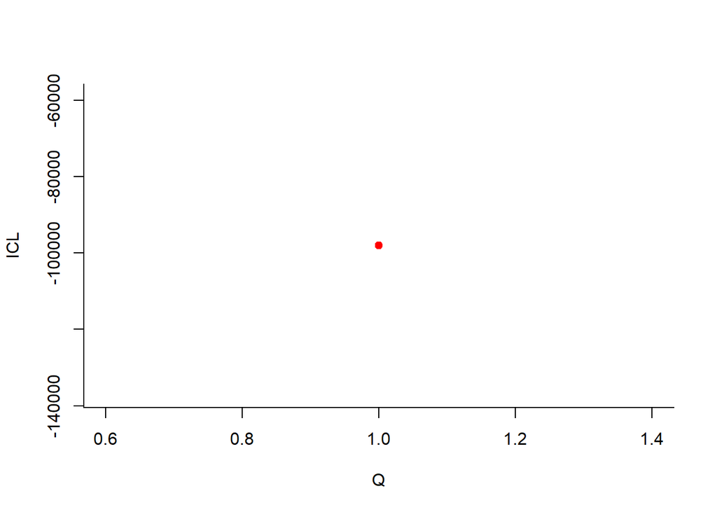

[output not shown]

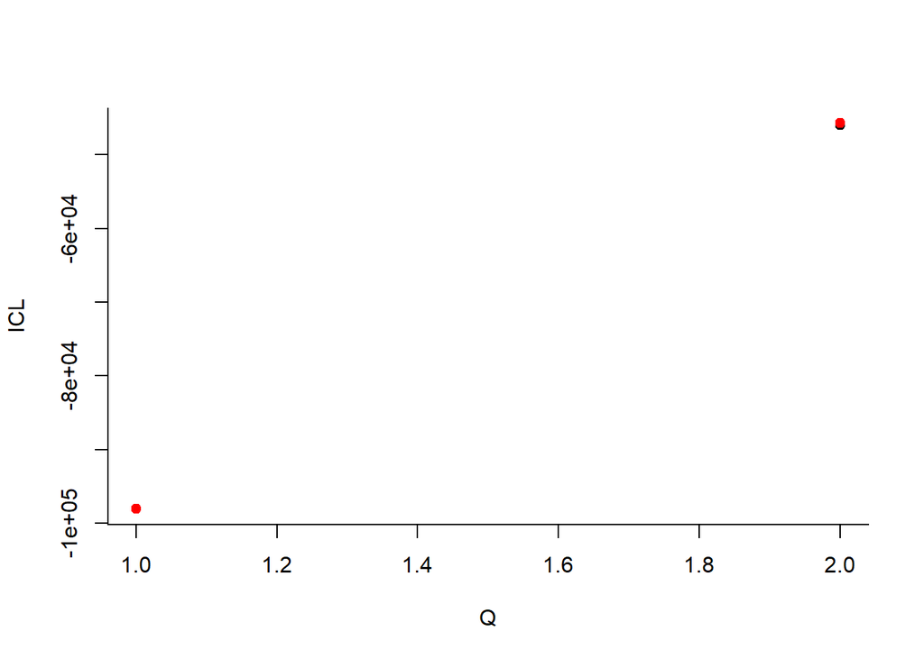

[output not shown]

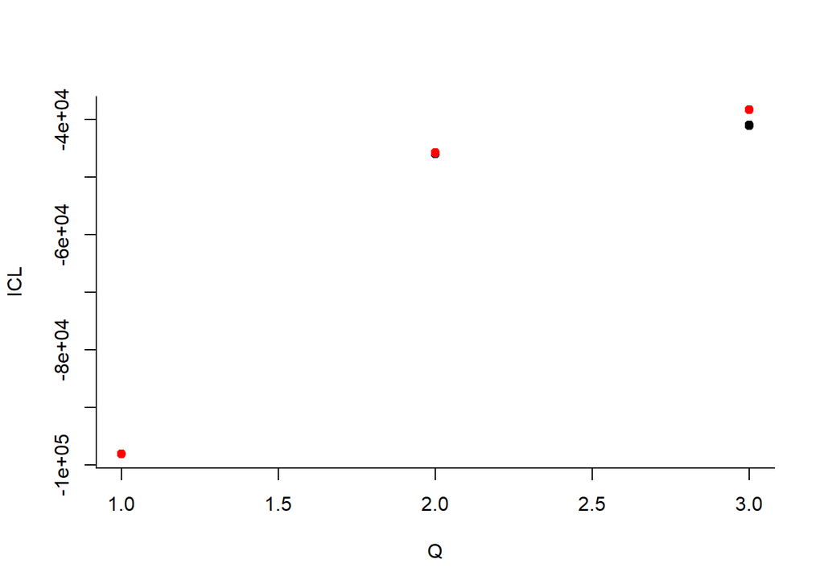

[output not shown]

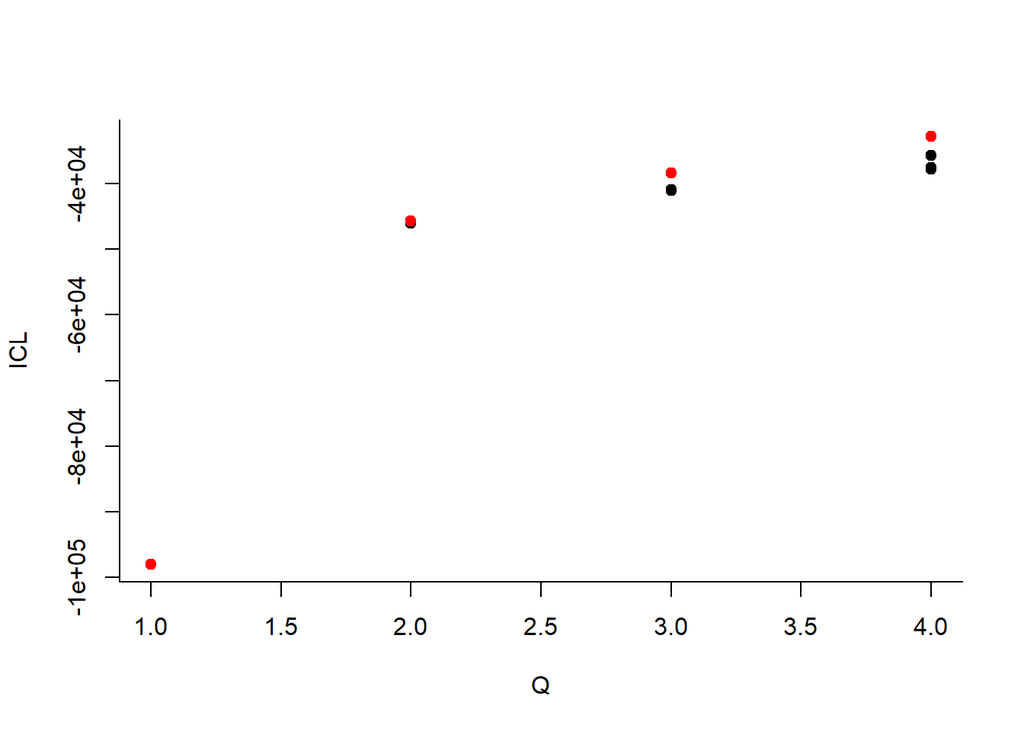

[output not shown]

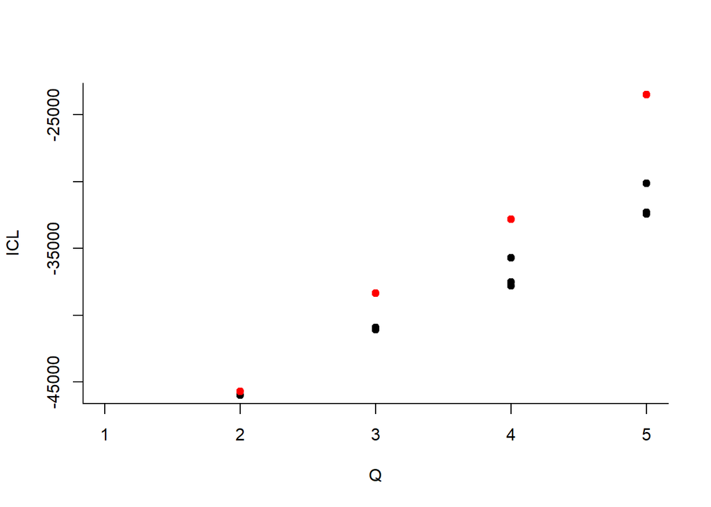

[output not shown]

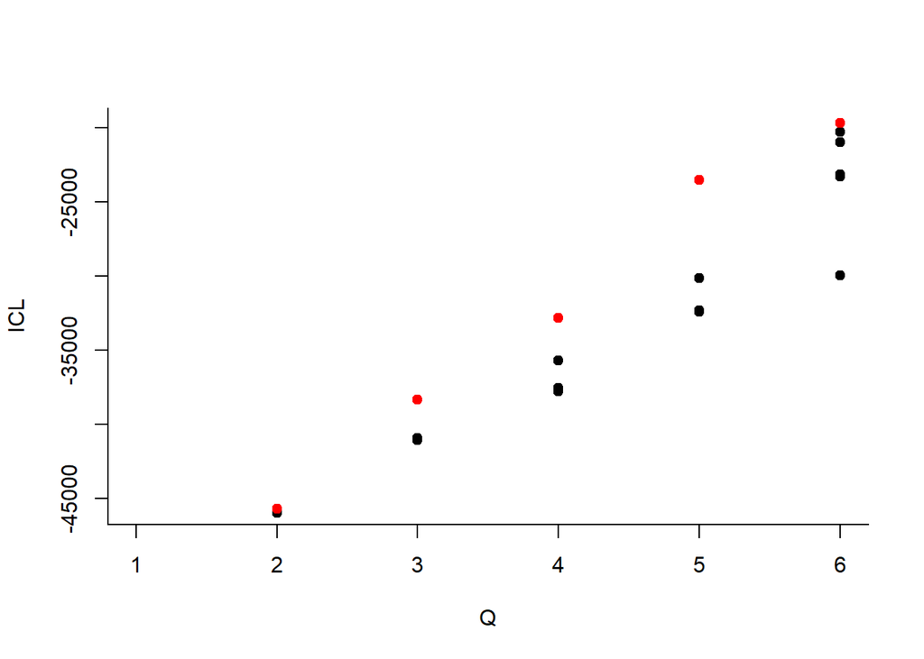

[output not shown]

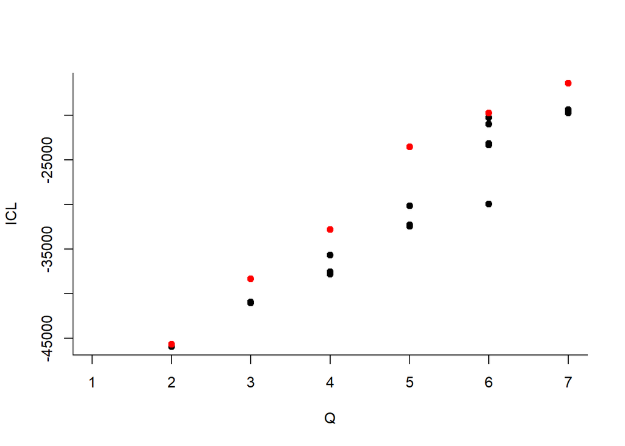

[output not shown]

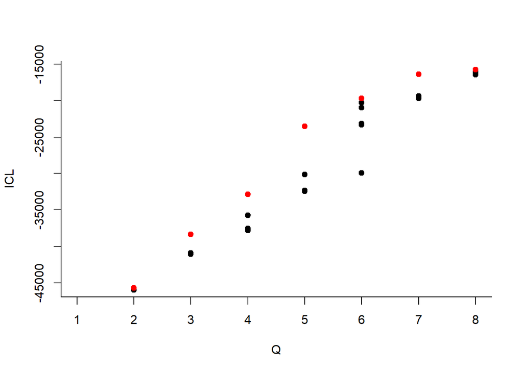

[output not shown]

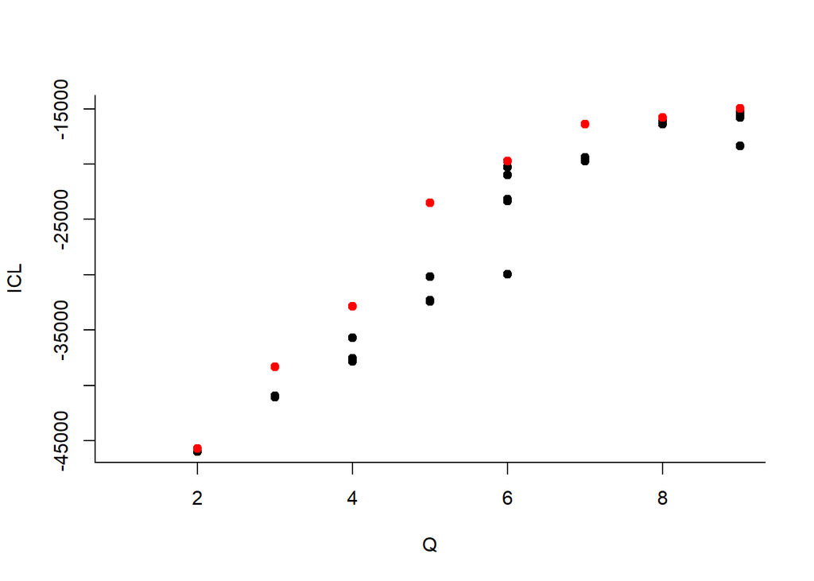

[output not shown]

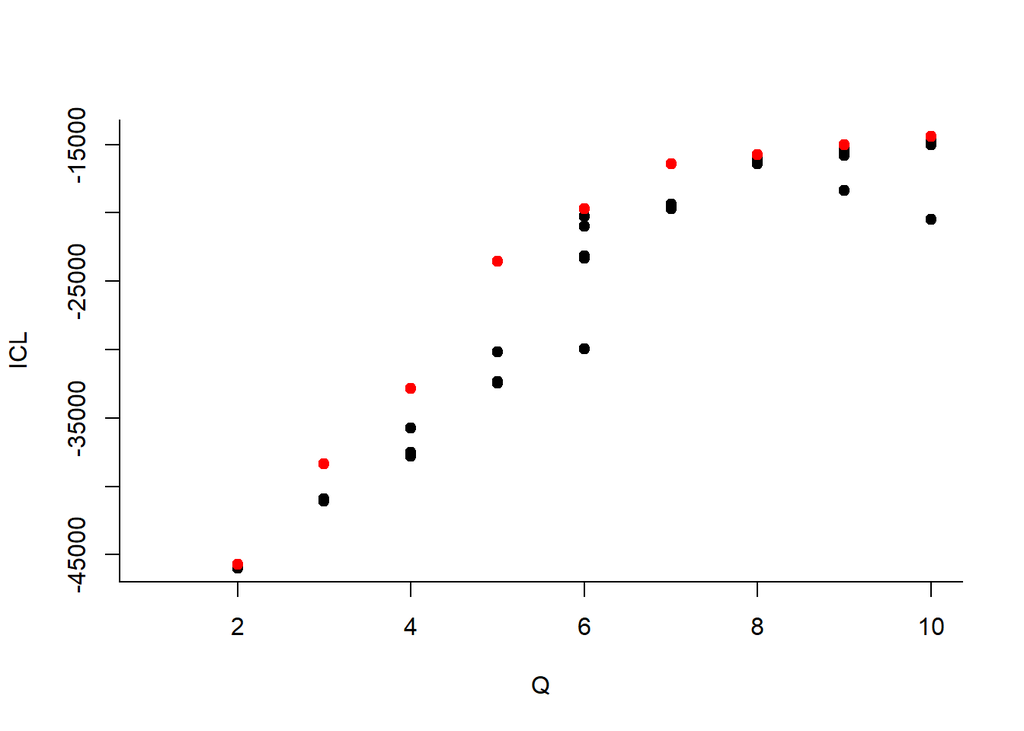

[output not shown]

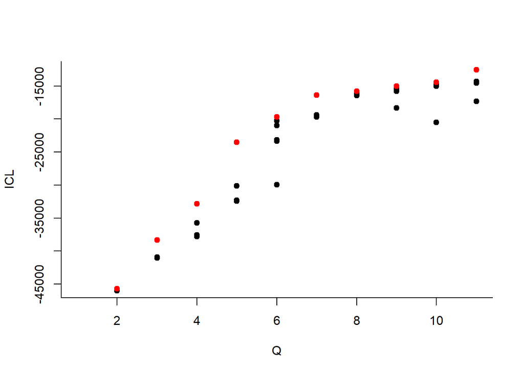

[output not shown]

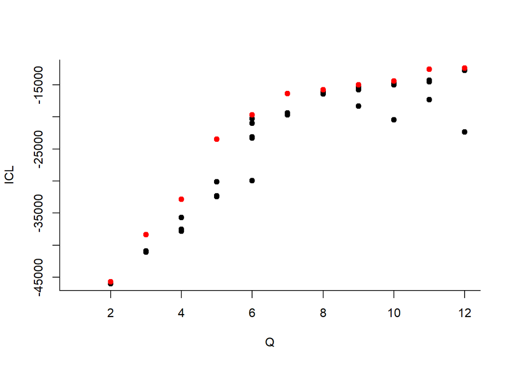

[output not shown]

[43 more figures not shown]

```r
if(sbm_done==0){
  metaweb=alltaxa_analysis$Metaweb
  metaweb$print()
  ### We remove resource nodes ###
  metaweb$graph=delete_vertices(metaweb$graph,c("R1","R2","R3"))
  metaweb$print()
  ### Actual clustering ###
  sbm_out=troph_sbm(metaweb,file_raw_adjacency,file_raw_weighted_adjacency,file_sbm_groups,file_sbm_adjacency,minim=10)
  #### Get learnt parameters ###
  trophic_groups=sbm_out$tg
  sbm_adj=sbm_out$adj
  sbm_done=1
}else{
  trophic_groups=read.csv2(file_sbm_groups,row.names=1)
  sbm_adj=read.csv2(file_sbm_adjacency,row.names = 1)
}
```

## Functional diversity

Analyzing the functional composition of our communities

```r
trophic_groups=read.csv2(file_sbm_groups,row.names = 1)
func_occur=merge(agg_occur,trophic_groups,by.x="key",by.y="keys")
agg_func_occur=aggregate(func_occur[,pt_names]>0,by = list(trophGroup=func_occur$trophic_group),FUN = sum)
fac_func_occur=data.frame(t(agg_func_occur[,2:dim(agg_func_occur)[2]]))
colnames(fac_func_occur)<-agg_func_occur$trophGroup

rf=cbind(fac,redund_fct(agg_func_occur,pt_names,eta=c(0,1,2)))
rf_counts=cbind(fac,fac_func_occur)

rm(fac_func_occur)
rm(fac_func_occur)
rm(agg_func_occur)
rm(func_occur)

write.csv2(rf,file=file_redund_fct,row.names = F)
write.csv2(rf_counts,file_agg_func_occur,row.names = F)
```

## Trophic groups betadiversity

At point level (64 points) of SBM groups

```r
eta=c(0,1,2)
divs=c('P','L')
if(sbmbetapt_done==0){
  gList=pointlevel_analysis$SubNetworks
  nodenames=V(getMetaweb(gList))$name
  nodegroups=unlist(lapply(nodenames,
                           function(x) as.character(
                             subset(trophic_groups,keys==x)[1,"trophic_group"])))
  names(nodegroups)=nodenames

  for (div in c('P','L')){
    for (e in eta){
      sbmbetadiv_ptdf=betanet(gList = gList,
                              groups=nodegroups,
                              pt_names = lnames,
                              div=div,
                              eta=e,
                              file_beta = paste(file_sbmbeta_pt,"_",e,"_",div,".csv",sep=""))
    }
  }

  sbmbetapt_done=1
}else{
  sbmbetadiv_ptdf=read.csv2(file_sbmbeta_pt,row.names = 1)
}
```

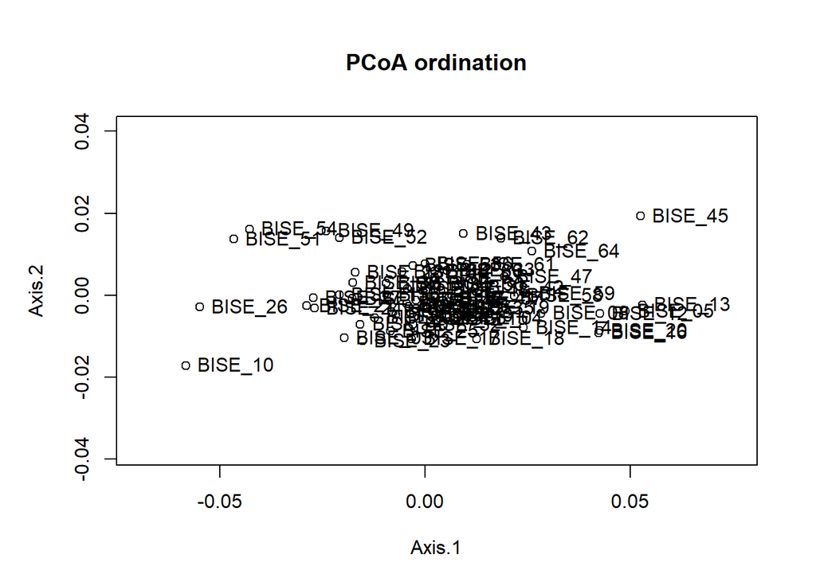

```r
x=pcoa_plot(D=as.dist(sbmbetadiv_ptdf),Y=NULL,corr="none")
```